# Сегментирование пользователей и анализ оттока клиентов банка

**Ссылка на файл презентации:** [Сегментация клиентов регионального банка и анализ оттока клиентов](https://drive.google.com/file/d/1FG03Gl4kMNS2m-u9YWzH56jGeN64RAb3/view?usp=sharing)

**Ссылка на дашборд:** [Интерактивный дашборд "Количество клиентов в зависимости от числа используемых продуктов"](https://public.tableau.com/app/profile/s.s6552/viz/clients_segments/Dashboard1?publish=yes)

**Цель проекта:** Разработка рекомендаций по снижению оттока клиентов.  
Результаты выполнения проекта позволят менеджеру продуктов получить рекомендации по развитию продуктов в разрезе сегментов клиентов для снижения оттока клиентов.

**Задача проекта:** Выделить сегменты клиентов регионального банка по количеству потребляемых продуктов с указанием характерных признаков каждого сегмента клиентов, а также значений или интервалов данных признаков. Привести рекомендации: продуктовые предложения по сегментам для снижения оттока клиентов.

**Исходные данные** — это данные о клиентах банка. Банк располагается в Ярославле и областных городах: Ростов Великий и Рыбинск.

**План работы по проекту:**

1. Загрузка библиотек и первичное знакомство с данными из файла bank_scrooge.csv
2. Провести предобработку данных.
3. Построить графики распределения признаков, матрицу корреляций признаков.
4. Выделить сегменты по числу используемых продуктов, построить графики распределения признаков по данным сегментам, связанных с оттоком клиентов.
5. Провести статистическую проверку гипотез.
6. Выделить характерные признаки каждого сегмента, с указанием значений или интервалов признаков, а также рекомендации -  
   продуктовые предложения по сегментам клиентов для снижения оттока клиентов.*
7. По итогам исследования подготовить презентацию.

## Загрузка библиотек и первичное знакомство с данными

```python
!pip install phik #загружаем модуль phik в окружение
```

```
     |████████████████████████████████| 679 kB 944 kB/s eta 0:00:01
```

```python
#загружаем необходимые модули
import pandas as pd
import matplotlib.pyplot as plt
import seaborn as sns
sns.set_style("darkgrid")
from scipy import stats as st
import numpy as np
import phik
from phik.report import plot_correlation_matrix
from phik import report
```

```python
#чтение файла с исходными данными и сохранение данных в переменную
bank_clients = pd.read_csv('bank_scrooge.csv')
```

```python
def get_df_name(df):            #функция получения имени проверяемого датафрейма
    name =[x for x in globals() if globals()[x] is df][0]
    return name

#Функция проверки датафрейма на дубликаты, пропуски, вывод информации
#о датафрейме, описат. статистики
def checking_data(df):

    print('Данные по датафрейму', get_df_name(df), ':')
    print()
    display(df.head())
    #Проверим наличие дубликатов строк
    print('Дубликатов строк в датафрейме:', df.duplicated().sum())
    print('')
    print('Количество пропусков в данных в столбцах:')
    empty_cells = df.isna().agg(['sum', 'mean']).T.rename(columns={'sum': 'total_blanks', 'mean': 'share_blanks, %'})
    empty_cells['total_blanks'] = empty_cells['total_blanks'].astype(int)
    empty_cells['share_blanks, %'] = round(empty_cells['share_blanks, %']*100, 2)
    display(empty_cells)
    print('')
    print('_'*25, 'dataframe info: ', '_'*25)
    # изучим информацию о типах данных в столбцах и размере датафрейма,
    #возможных пропусках в данных
    df.info()
    print('')
    #попытаемся понять, есть ли аномальные значения
    print('Описательная статистика датафрейма:')
    display(df.describe(include = "all").round(2));
```

```python
#проверяем датафрейм logs на дубликаты, пропуски, вывод информации
#о датафрейме,описат. статистики
print(checking_data(bank_clients));
```

```
Данные по датафрейму bank_clients :
```

|  | USERID | score | city | gender | age | equity | balance | products | credit_card | last_activity | EST_SALARY | churn |
| --- | --- | --- | --- | --- | --- | --- | --- | --- | --- | --- | --- | --- |
| 0 | 183012 | 850.0 | Рыбинск | Ж | 25.0 | 1 | 59214.82 | 2 | 0 | 1 | 75719.14 | 1 |
| 1 | 146556 | 861.0 | Рыбинск | Ж | 37.0 | 5 | 850594.33 | 3 | 1 | 0 | 86621.77 | 0 |
| 2 | 120722 | 892.0 | Рыбинск | Ж | 30.0 | 0 | NaN | 1 | 1 | 1 | 107683.34 | 0 |
| 3 | 225363 | 866.0 | Ярославль | Ж | 51.0 | 5 | 1524746.26 | 2 | 0 | 1 | 174423.53 | 1 |
| 4 | 157978 | 730.0 | Ярославль | М | 34.0 | 5 | 174.00 | 1 | 1 | 0 | 67353.16 | 1 |

```
Дубликатов строк в датафрейме: 0

Количество пропусков в данных в столбцах:
```

|  | total_blanks | share_blanks, % |
| --- | --- | --- |
| USERID | 0 | 0.00 |
| score | 0 | 0.00 |
| city | 0 | 0.00 |
| gender | 0 | 0.00 |
| age | 26 | 0.26 |
| equity | 0 | 0.00 |
| balance | 2295 | 22.95 |
| products | 0 | 0.00 |
| credit_card | 0 | 0.00 |
| last_activity | 0 | 0.00 |
| EST_SALARY | 0 | 0.00 |
| churn | 0 | 0.00 |

```
_________________________ dataframe info:  _________________________
<class 'pandas.core.frame.DataFrame'>
RangeIndex: 10000 entries, 0 to 9999
Data columns (total 12 columns):
 #   Column         Non-Null Count  Dtype
---  ------         --------------  -----
 0   USERID         10000 non-null  int64
 1   score          10000 non-null  float64
 2   city           10000 non-null  object
 3   gender         10000 non-null  object
 4   age            9974 non-null   float64
 5   equity         10000 non-null  int64
 6   balance        7705 non-null   float64
 7   products       10000 non-null  int64
 8   credit_card    10000 non-null  int64
 9   last_activity  10000 non-null  int64
 10  EST_SALARY     10000 non-null  float64
 11  churn          10000 non-null  int64
dtypes: float64(4), int64(6), object(2)
memory usage: 937.6+ KB

Описательная статистика датафрейма:
```

|  | USERID | score | city | gender | age | equity | balance | products | credit_card | last_activity | EST_SALARY | churn |
| --- | --- | --- | --- | --- | --- | --- | --- | --- | --- | --- | --- | --- |
| count | 10000.00 | 10000.00 | 10000 | 10000 | 9974.00 | 10000.00 | 7.705000e+03 | 10000.00 | 10000.00 | 10000.00 | 10000.00 | 10000.00 |
| unique | NaN | NaN | 3 | 2 | NaN | NaN | NaN | NaN | NaN | NaN | NaN | NaN |
| top | NaN | NaN | Ярославль | М | NaN | NaN | NaN | NaN | NaN | NaN | NaN | NaN |
| freq | NaN | NaN | 5888 | 5005 | NaN | NaN | NaN | NaN | NaN | NaN | NaN | NaN |
| mean | 171814.71 | 848.70 | NaN | NaN | 42.73 | 2.63 | 8.277943e+05 | 1.87 | 0.68 | 0.52 | 147866.89 | 0.18 |
| std | 33708.24 | 65.45 | NaN | NaN | 12.18 | 1.98 | 1.980614e+06 | 0.79 | 0.47 | 0.50 | 139388.51 | 0.39 |
| min | 94561.00 | 642.00 | NaN | NaN | 18.00 | 0.00 | 0.000000e+00 | 0.00 | 0.00 | 0.00 | 2546.30 | 0.00 |
| 25% | 142810.25 | 802.00 | NaN | NaN | 33.00 | 0.00 | 2.955542e+05 | 1.00 | 0.00 | 0.00 | 75251.90 | 0.00 |
| 50% | 172728.00 | 853.00 | NaN | NaN | 40.00 | 3.00 | 5.242722e+05 | 2.00 | 1.00 | 1.00 | 119658.10 | 0.00 |
| 75% | 201261.75 | 900.00 | NaN | NaN | 51.00 | 4.00 | 9.807058e+05 | 2.00 | 1.00 | 1.00 | 174500.54 | 0.00 |
| max | 229145.00 | 1000.00 | NaN | NaN | 86.00 | 9.00 | 1.191136e+08 | 5.00 | 1.00 | 1.00 | 1395064.45 | 1.00 |

```
None
```

**Подитог по разделу 1:**  
В таблице bank_clients 10000 строк, полных дубликатов-строк нет.  
Пропуски только в колонках age (26 шт. или 0.26%) и balance (2295 шт. или 22.95%). Пропуски в колонке balance проанализируем дальше, а строки с пропусками в колонке age удалим.  
В колонке score: значения в диапазоне 642-1000, age: 18-86, equity: 0-9, balance: 0- 119113552.01, products: 0-5, credit_card: 0-1, last_activity: 0-1, EST_SALARY: 2546.30 - 1395064.45, churn: 0-1.  
Странным выглядит наличие клиентов с нулевым значением продуктов. Необходимо посмотреть сколько таких клиентов и удалить, если их немного.  
Помимо этого, аномальных значений в числовых данных не наблюдается.  
Можно было бы уточнить - действительно ли максимальные значения в колонке EST_SALARY 1395064.45 и значение 119113552.01 в колонке balance имеют релевантность. Но, скорее всего, эти значения не аномалия и их необходимо учесть далее в анализе.

В колонках age, score необходимо сменить тип данных с float на int, так как в них целочисленные значения.

## Предобработка данных

```python
#переводим названия столбцов USERID и EST_SALARY в нижний регистр
bank_clients.columns = bank_clients.columns.str.lower()
```

### Обработка пропусков в колонке age

```python
#запишем userid строк с пропусками в колонке age в отдельный список  |
empty_age=bank_clients[bank_clients['age'].isna()]['userid'].reset_index(drop=True)
```

```python
#запишем userid строк с дубликатами userid в отдельный список.
dupl_userid=bank_clients[bank_clients.duplicated(subset=['userid'])]['userid'].reset_index(drop=True)
```

```python
#выведем строки с пропущенным значением в колонке age, но имеющие дубликат userid
display(bank_clients[(bank_clients['userid'].isin(empty_age))&(bank_clients['userid'].isin(dupl_userid))]\
       .sort_values(by='userid', ascending=True))
```

|  | userid | score | city | gender | age | equity | balance | products | credit_card | last_activity | est_salary | churn |
| --- | --- | --- | --- | --- | --- | --- | --- | --- | --- | --- | --- | --- |
| 8785 | 127440 | 663.0 | Ярославль | М | NaN | 0 | NaN | 1 | 1 | 1 | 117197.56 | 0 |
| 4443 | 127440 | 846.0 | Рыбинск | М | 66.0 | 1 | 57405.67 | 2 | 0 | 1 | 17831.63 | 0 |
| 9819 | 140934 | 832.0 | Рыбинск | Ж | NaN | 3 | 385763.16 | 2 | 0 | 1 | 59651.35 | 0 |
| 4212 | 140934 | 919.0 | Ярославль | Ж | 29.0 | 4 | 603946.18 | 3 | 0 | 1 | 158438.79 | 0 |
| 4343 | 141945 | 929.0 | Рыбинск | М | 33.0 | 0 | NaN | 1 | 1 | 0 | 381868.89 | 0 |
| 9457 | 141945 | 929.0 | Ярославль | М | NaN | 0 | NaN | 1 | 1 | 0 | 381868.89 | 0 |
| 5495 | 151662 | 884.0 | Рыбинск | Ж | NaN | 0 | NaN | 1 | 1 | 1 | 137500.77 | 0 |
| 3683 | 151662 | 960.0 | Ярославль | Ж | 37.0 | 4 | 2527032.70 | 4 | 1 | 0 | 231648.50 | 0 |
| 6670 | 163657 | 903.0 | Рыбинск | М | 45.0 | 4 | 1343339.70 | 4 | 0 | 1 | 83741.65 | 0 |
| 9667 | 163657 | 849.0 | Ярославль | М | NaN | 4 | 1254013.85 | 2 | 1 | 1 | 119106.67 | 0 |
| 3668 | 185829 | 925.0 | Рыбинск | М | 40.0 | 0 | NaN | 1 | 1 | 0 | 228305.64 | 0 |
| 9632 | 185829 | 927.0 | Ярославль | М | NaN | 0 | NaN | 1 | 1 | 0 | 231254.86 | 0 |
| 4720 | 187459 | 895.0 | Ярославль | М | 48.0 | 0 | NaN | 1 | 1 | 0 | 180887.50 | 0 |
| 9380 | 187459 | 894.0 | Рыбинск | М | NaN | 0 | NaN | 1 | 1 | 0 | 178012.28 | 0 |
| 2165 | 187635 | 692.0 | Рыбинск | Ж | NaN | 0 | NaN | 1 | 1 | 1 | 160368.82 | 0 |
| 918 | 187635 | 918.0 | Ярославль | Ж | 44.0 | 0 | NaN | 1 | 1 | 1 | 162497.52 | 0 |
| 1181 | 198635 | 896.0 | Рыбинск | Ж | 32.0 | 0 | NaN | 1 | 1 | 1 | 170866.01 | 0 |
| 8015 | 198635 | 670.0 | Ярославль | Ж | NaN | 0 | NaN | 1 | 1 | 1 | 168699.33 | 0 |
| 8897 | 202983 | 941.0 | Ярославль | Ж | 39.0 | 0 | NaN | 1 | 0 | 1 | 159348.84 | 0 |
| 9301 | 202983 | 942.0 | Рыбинск | Ж | NaN | 0 | NaN | 1 | 1 | 1 | 163804.73 | 0 |
| 5889 | 206759 | 917.0 | Ярославль | М | 22.0 | 0 | NaN | 1 | 1 | 0 | 70617.52 | 0 |
| 8385 | 206759 | 915.0 | Рыбинск | М | NaN | 0 | NaN | 1 | 1 | 0 | 71179.53 | 0 |
| 3230 | 210135 | 974.0 | Ярославль | Ж | 50.0 | 5 | 5680148.93 | 4 | 1 | 1 | 338471.66 | 0 |
| 7236 | 210135 | 908.0 | Рыбинск | Ж | NaN | 4 | 1120340.31 | 3 | 1 | 1 | 85002.15 | 0 |
| 8449 | 210898 | 805.0 | Ярославль | Ж | NaN | 0 | NaN | 1 | 0 | 1 | 922080.25 | 0 |
| 6685 | 210898 | 934.0 | Рыбинск | Ж | 35.0 | 0 | NaN | 1 | 0 | 1 | 912105.84 | 0 |
| 7409 | 214031 | 777.0 | Ярославль | М | NaN | 2 | 171510.23 | 1 | 1 | 1 | 75409.63 | 0 |
| 431 | 214031 | 856.0 | Рыбинск | М | 36.0 | 2 | 386426.67 | 4 | 1 | 1 | 72767.85 | 0 |
| 8293 | 216848 | 930.0 | Ярославль | М | NaN | 0 | NaN | 1 | 1 | 1 | 199542.51 | 0 |
| 4401 | 216848 | 929.0 | Рыбинск | М | 68.0 | 0 | NaN | 1 | 1 | 1 | 195902.59 | 0 |
| 7 | 218868 | 825.0 | Ярославль | Ж | 38.0 | 4 | 458145.40 | 2 | 1 | 1 | 68085.48 | 0 |
| 5470 | 218868 | 827.0 | Рыбинск | Ж | NaN | 4 | 448959.07 | 2 | 1 | 1 | 67835.95 | 0 |
| 7248 | 219343 | 920.0 | Рыбинск | Ж | NaN | 0 | NaN | 1 | 1 | 0 | 159248.67 | 0 |
| 1010 | 219343 | 921.0 | Ярославль | Ж | 33.0 | 0 | NaN | 1 | 1 | 0 | 159475.61 | 0 |
| 2444 | 221156 | 913.0 | Ярославль | М | NaN | 0 | NaN | 1 | 1 | 1 | 135693.24 | 0 |
| 1389 | 221156 | 687.0 | Рыбинск | М | 61.0 | 0 | NaN | 1 | 1 | 1 | 136361.72 | 0 |
| 8632 | 221197 | 893.0 | Ярославль | М | NaN | 0 | NaN | 1 | 1 | 0 | 173929.92 | 0 |
| 440 | 221197 | 663.0 | Рыбинск | М | 27.0 | 0 | NaN | 1 | 1 | 1 | 172573.13 | 0 |
| 9322 | 221809 | 917.0 | Рыбинск | М | 45.0 | 0 | NaN | 1 | 1 | 1 | 199728.29 | 0 |
| 9634 | 221809 | 917.0 | Ярославль | М | NaN | 0 | NaN | 1 | 1 | 1 | 192644.15 | 0 |
| 9104 | 222480 | 776.0 | Рыбинск | Ж | NaN | 5 | 796735.09 | 1 | 1 | 1 | 55073.63 | 0 |
| 6446 | 222480 | 776.0 | Ярославль | Ж | 38.0 | 5 | 823145.83 | 2 | 1 | 1 | 55777.44 | 0 |
| 6412 | 226550 | 939.0 | Ярославль | М | 34.0 | 0 | NaN | 1 | 1 | 1 | 145913.73 | 0 |
| 8070 | 226550 | 940.0 | Рыбинск | М | NaN | 0 | NaN | 1 | 0 | 1 | 147696.95 | 0 |
| 6457 | 228075 | 839.0 | Рыбинск | М | 39.0 | 5 | 507199.85 | 3 | 0 | 1 | 85195.80 | 0 |
| 1247 | 228075 | 932.0 | Ярославль | М | NaN | 5 | 7601719.20 | 2 | 1 | 1 | 408121.16 | 0 |

Среди клиентов с пропуском в колонке age только у клинета с userid 141945 (с индексом 9457) полное совпадение профиля с данными в строке-дубликате по userid, если рассматривать колонки score, gender, products, credit_cards, last_activity, est_salary. Таким образом можно говорить, что это один и тот же клиент, но находящийся в двух филиалах - Рыбинске и Ярославле, и значение для пропуска в колонке age взять из строки-дубликата.  
Также для целей данного анализа будем считать, что клиента с userid 141945 можем оставить только в Ярославле, а строку, связанную с Рыбинском (индекс 4343), удалим, т.к. это полный дубликат.  
По остальным клиентам, есть похожие строки-дубликаты, но они не так явно совпадают, и это, скорее всего, разные клиенты. Поэтому взять данные для заполнения колонки age мы оттуда не можем.

```python
#указываем значение из строки-дубликата для пропуска в колонке age по
#клиенту с userid 141945 (с индексом 9457)
bank_clients.loc[9457, 'age']=33
```

Т.к. остальные пропуски в колонке age заполнить не можем, удалим их.

```python
#удаляем строки с пропусками в колонке age
bank_clients.dropna(subset=['age'], inplace = True)
```

### Обработка дубликатов в колонке userid

```python
#удалим строку с индексом 4343, как решили выше, как полный дубликат по клиенту с userid 141945
bank_clients.drop(labels = [4343], axis = 0, inplace = True)
```

```python
#проверим userid, продублированные в данных о клиентах
print('Количество значений userid, продублированных в данных о клиентах:', \
      bank_clients.groupby('userid', as_index=False)['score']\
      .count().query('score > 1')['score'].count())

print('Количество строк о клиентах согласно данным из файла:', \
     bank_clients.shape[0])
print('Доля строк-дубликатов в колонке userid от общего количества: ', round(\
     ((bank_clients.groupby('userid', as_index=False)['score'].count().query('score > 1')['score'].sum()\
     - bank_clients.groupby('userid', as_index=False)['score'].count().query('score > 1')['score'].count())\
     /bank_clients.shape[0])*100, 2), '%')
```

```
Количество значений userid, продублированных в данных о клиентах: 50
Количество строк о клиентах согласно данным из файла: 9974
Доля строк-дубликатов в колонке userid от общего количества:  0.5 %
```

```python
#строки имеющие дубликат userid, чтобы проверить совпадение данных
pd.set_option('display.max_rows', None)
display(bank_clients[(bank_clients['userid'].isin(dupl_userid))]\
       .sort_values(by='userid', ascending=True))
pd.reset_option('display.max_rows', None)
```

|  | userid | score | city | gender | age | equity | balance | products | credit_card | last_activity | est_salary | churn |
| --- | --- | --- | --- | --- | --- | --- | --- | --- | --- | --- | --- | --- |
| 7694 | 116540 | 887.0 | Ярославль | Ж | 38.0 | 0 | NaN | 1 | 0 | 1 | 119247.61 | 0 |
| 1893 | 116540 | 883.0 | Рыбинск | Ж | 55.0 | 1 | 362756.49 | 3 | 0 | 1 | 175920.48 | 1 |
| 7542 | 117943 | 880.0 | Ярославль | Ж | 40.0 | 0 | NaN | 1 | 1 | 0 | 137718.93 | 0 |
| 4866 | 117943 | 855.0 | Рыбинск | Ж | 32.0 | 6 | 1036832.93 | 4 | 1 | 1 | 107792.71 | 1 |
| 5896 | 120258 | 905.0 | Ярославль | М | 30.0 | 0 | NaN | 1 | 1 | 1 | 146427.96 | 0 |
| 5863 | 120258 | 908.0 | Рыбинск | Ж | 38.0 | 4 | 2213581.63 | 2 | 0 | 1 | 160327.77 | 1 |
| 8638 | 123461 | 934.0 | Рыбинск | М | 34.0 | 0 | NaN | 2 | 1 | 0 | 291619.27 | 0 |
| 1411 | 123461 | 829.0 | Ярославль | Ж | 59.0 | 0 | 96222.44 | 2 | 0 | 1 | 102771.55 | 1 |
| 9775 | 124450 | 758.0 | Рыбинск | Ж | 36.0 | 0 | 73574.07 | 2 | 0 | 1 | 79963.59 | 0 |
| 8164 | 124450 | 859.0 | Ярославль | Ж | 38.0 | 6 | 516811.20 | 1 | 1 | 1 | 95144.63 | 1 |
| 5420 | 126368 | 832.0 | Рыбинск | Ж | 33.0 | 0 | NaN | 1 | 0 | 0 | 118465.34 | 0 |
| 4850 | 126368 | 909.0 | Ярославль | Ж | 30.0 | 4 | 1322623.29 | 2 | 0 | 1 | 140675.66 | 1 |
| 4443 | 127440 | 846.0 | Рыбинск | М | 66.0 | 1 | 57405.67 | 2 | 0 | 1 | 17831.63 | 0 |
| 3988 | 129785 | 904.0 | Рыбинск | М | 33.0 | 5 | 2427737.60 | 3 | 0 | 1 | 188856.75 | 1 |
| 9504 | 129785 | 949.0 | Ярославль | М | 43.0 | 0 | NaN | 1 | 1 | 1 | 166845.37 | 0 |
| 904 | 131419 | 934.0 | Ярославль | М | 35.0 | 5 | 2348335.95 | 2 | 0 | 0 | 217105.13 | 1 |
| 2138 | 131419 | 739.0 | Рыбинск | Ж | 37.0 | 3 | 1307941.65 | 3 | 0 | 0 | 103867.47 | 0 |
| 7487 | 140377 | 930.0 | Рыбинск | Ж | 34.0 | 5 | 1123967.02 | 1 | 1 | 1 | 148336.26 | 0 |
| 1608 | 140377 | 802.0 | Ярославль | М | 26.0 | 3 | 539863.29 | 4 | 1 | 1 | 112167.83 | 1 |
| 4212 | 140934 | 919.0 | Ярославль | Ж | 29.0 | 4 | 603946.18 | 3 | 0 | 1 | 158438.79 | 0 |
| 2276 | 141265 | 858.0 | Ярославль | М | 37.0 | 4 | 471599.16 | 2 | 1 | 1 | 148806.88 | 1 |
| 5569 | 141265 | 811.0 | Рыбинск | Ж | 33.0 | 3 | 1044316.88 | 2 | 1 | 0 | 46055.32 | 0 |
| 9457 | 141945 | 929.0 | Ярославль | М | 33.0 | 0 | NaN | 1 | 1 | 0 | 381868.89 | 0 |
| 5369 | 143592 | 885.0 | Рыбинск | Ж | 56.0 | 4 | 1201087.46 | 2 | 1 | 1 | 88223.89 | 1 |
| 5557 | 143592 | 764.0 | Ярославль | Ж | 68.0 | 3 | 508919.15 | 2 | 0 | 1 | 71211.66 | 0 |
| 5252 | 148826 | 895.0 | Ярославль | М | 32.0 | 5 | 1470273.14 | 2 | 0 | 0 | 118058.52 | 1 |
| 8364 | 148826 | 909.0 | Рыбинск | Ж | 32.0 | 0 | NaN | 3 | 1 | 0 | 28843.54 | 0 |
| 8272 | 149365 | 793.0 | Рыбинск | Ж | 61.0 | 0 | 476496.99 | 2 | 1 | 1 | 46147.06 | 0 |
| 946 | 149365 | 877.0 | Ярославль | М | 41.0 | 5 | 819182.01 | 2 | 0 | 0 | 212316.47 | 1 |
| 9267 | 150667 | 931.0 | Ярославль | М | 41.0 | 0 | NaN | 1 | 0 | 0 | 261904.44 | 0 |

[output cut: 93 more lines]

По данным клиентам, есть похожие строки-дубликаты с близкими значениями некоторых параметров, но они явно не совпадают. И это, скорее всего, разные клиенты. Поэтому строки удалять не будем, просто произведем новую условную нумерацию колонки userid, чтобы дубликатов в этой колонке больше не было.

```python
#количество полных дубликатов по всем признакам за исключением userid и churn.
print('количество полных дубликатов по всем признакам за исключением userid и churn:', \
       bank_clients.duplicated(subset=['score', 'city', 'gender', 'age', 'equity', 'balance', 'products',\
       'credit_card', 'last_activity', 'est_salary']).sum())
```

```
количество полных дубликатов по всем признакам за исключением userid и churn: 0
```

```python
#количество полных дубликатов по всем признакам за исключением userid, city, churn.
print('количество полных дубликатов по всем признакам за исключением userid, city, churn:', \
       bank_clients.duplicated(subset=['score', 'gender', 'age', 'equity', 'balance', 'products',\
       'credit_card', 'last_activity', 'est_salary']).sum())
```

```
количество полных дубликатов по всем признакам за исключением userid, city, churn: 0
```

```python
#количество полных дубликатов по всем признакам за исключением
#userid, churn, city, balance, 'products','credit_card', last_activity.
print('количество полных дубликатов по признакам score, gender, age, equity, est_salary:', \
       bank_clients.duplicated(subset=['score', 'gender', 'age', 'equity', 'est_salary']).sum())
```

```
количество полных дубликатов по признакам score, gender, age, equity, est_salary: 0
```

Не выявлено неявных дубликатов строк, которые напоминали бы одного клиента по пересечению одновременно в колонках score, gender, age, equity, est_salary (или с еще большим количеством признаков сразу, но исключая признак userid).

```python
#всю колонку userid полностью перенумеровываем, чтобы дубликатов userid не было, сбрасываем начальную нумерацию.
bank_clients['userid'] = bank_clients.reset_index().index
bank_clients.reset_index(inplace = True, drop=True)
```

### Проверка неявных дубликатов в колонках city, gender, строк с нулевым количеством продуктов

```python
#проверим количество уникальных значений в колонке city
print('Набор значений колонки city: ', bank_clients['city'].unique())

#проверим количество уникальных значений в колонке gender
print('Набор значений колонки gender: ', bank_clients['gender'].unique())
```

```
Набор значений колонки city:  ['Рыбинск' 'Ярославль' 'Ростов']
Набор значений колонки gender:  ['Ж' 'М']
```

В колонках city и gender нет неявных дубликатов, только необходимые категорийные значения.

```python
#проверяем количество клиентов с нулевым значением продуктов
print('Количество клиентов с нулевым значением колонки products: ',\
      bank_clients.query('products==0')['products'].count())
```

```
Количество клиентов с нулевым значением колонки products:  1
```

Так как у нас всего один клиент с нулевым значением продуктов, удалим эту строку.

```python
#удалим строку, содержащую нулевое значение колонки product
bank_clients.drop(bank_clients.query('products==0').index, inplace = True)

#проверка
print('Количество клиентов с нулевым значением колонки products: ',\
      bank_clients.query('products==0')['products'].count())
```

```
Количество клиентов с нулевым значением колонки products:  0
```

```python
#меняем тип дынных в колонках age, score c float на int (после удаления пропусков)
bank_clients['age'] = bank_clients['age'].round(0).astype(int)
bank_clients['score'] = bank_clients['score'].astype(int)
bank_clients.info()
```

```
<class 'pandas.core.frame.DataFrame'>
Int64Index: 9973 entries, 0 to 9973
Data columns (total 12 columns):
 #   Column         Non-Null Count  Dtype
---  ------         --------------  -----
 0   userid         9973 non-null   int64
 1   score          9973 non-null   int64
 2   city           9973 non-null   object
 3   gender         9973 non-null   object
 4   age            9973 non-null   int64
 5   equity         9973 non-null   int64
 6   balance        7695 non-null   float64
 7   products       9973 non-null   int64
 8   credit_card    9973 non-null   int64
 9   last_activity  9973 non-null   int64
 10  est_salary     9973 non-null   float64
 11  churn          9973 non-null   int64
dtypes: float64(2), int64(8), object(2)
memory usage: 1012.9+ KB
```

### Обработка пропусков в колонке balance

```python
#посмотрим, как маркируются пропуски в колонке balance
print('Значения столбца balance кроме числовых в имеющихся данных:', \
      bank_clients['balance'].map(lambda x: x if not(x > 0) else 0).unique())
```

```
Значения столбца balance кроме числовых в имеющихся данных: [ 0. nan]
```

В стобце balance имеем только значения 'NaN', 0 и значения больше нуля. Других значений нет. Так как здесь уже есть нули, то заполнять пропуски нулями не будем, чтобы не смешать разные по смыслу данные.

Сравним данные, содержащие пропуски в колонке balance, с данными без пропусков в колонке balance и проанализируем данные.

```python
#Описательная статистика датафрейма с пропусками в колонке balance
print('Описательная статистика датафрейма с пропусками в колонке balance:')
bank_clients[bank_clients['balance'].isna()].describe(include = "all").round(2)
```

```
Описательная статистика датафрейма с пропусками в колонке balance:
```

|  | userid | score | city | gender | age | equity | balance | products | credit_card | last_activity | est_salary | churn |
| --- | --- | --- | --- | --- | --- | --- | --- | --- | --- | --- | --- | --- |
| count | 2278.00 | 2278.00 | 2278 | 2278 | 2278.00 | 2278.00 | 0.0 | 2278.00 | 2278.00 | 2278.00 | 2278.00 | 2278.00 |
| unique | NaN | NaN | 3 | 2 | NaN | NaN | NaN | NaN | NaN | NaN | NaN | NaN |
| top | NaN | NaN | Ярославль | М | NaN | NaN | NaN | NaN | NaN | NaN | NaN | NaN |
| freq | NaN | NaN | 1459 | 1272 | NaN | NaN | NaN | NaN | NaN | NaN | NaN | NaN |
| mean | 4955.34 | 865.31 | NaN | NaN | 42.08 | 0.05 | NaN | 1.16 | 0.82 | 0.55 | 226433.78 | 0.01 |
| std | 2870.41 | 89.55 | NaN | NaN | 11.92 | 0.22 | NaN | 0.40 | 0.39 | 0.50 | 199824.93 | 0.07 |
| min | 2.00 | 642.00 | NaN | NaN | 18.00 | 0.00 | NaN | 1.00 | 0.00 | 0.00 | 20274.03 | 0.00 |
| 25% | 2487.25 | 871.00 | NaN | NaN | 33.00 | 0.00 | NaN | 1.00 | 1.00 | 0.00 | 120269.55 | 0.00 |
| 50% | 4868.50 | 903.00 | NaN | NaN | 40.00 | 0.00 | NaN | 1.00 | 1.00 | 1.00 | 174354.24 | 0.00 |
| 75% | 7416.25 | 922.00 | NaN | NaN | 49.00 | 0.00 | NaN | 1.00 | 1.00 | 1.00 | 240396.96 | 0.00 |
| max | 9971.00 | 990.00 | NaN | NaN | 86.00 | 1.00 | NaN | 3.00 | 1.00 | 1.00 | 1333687.36 | 1.00 |

```python
#Описательная статистика датафрейма без пропусков в колонке balance
print('Описательная статистика датафрейма без пропусков в колонке balance:')
bank_clients[bank_clients['balance'].notnull()].describe(include = "all").round(2)
```

```
Описательная статистика датафрейма без пропусков в колонке balance:
```

|  | userid | score | city | gender | age | equity | balance | products | credit_card | last_activity | est_salary | churn |
| --- | --- | --- | --- | --- | --- | --- | --- | --- | --- | --- | --- | --- |
| count | 7695.00 | 7695.00 | 7695 | 7695 | 7695.00 | 7695.00 | 7.695000e+03 | 7695.00 | 7695.00 | 7695.00 | 7695.00 | 7695.00 |
| unique | NaN | NaN | 3 | 2 | NaN | NaN | NaN | NaN | NaN | NaN | NaN | NaN |
| top | NaN | NaN | Ярославль | Ж | NaN | NaN | NaN | NaN | NaN | NaN | NaN | NaN |
| freq | NaN | NaN | 4417 | 3976 | NaN | NaN | NaN | NaN | NaN | NaN | NaN | NaN |
| mean | 4995.21 | 843.74 | NaN | NaN | 42.92 | 3.39 | 8.272456e+05 | 2.08 | 0.64 | 0.52 | 124520.39 | 0.23 |
| std | 2882.00 | 55.34 | NaN | NaN | 12.24 | 1.58 | 1.980327e+06 | 0.76 | 0.48 | 0.50 | 104667.11 | 0.42 |
| min | 0.00 | 689.00 | NaN | NaN | 18.00 | 0.00 | 0.000000e+00 | 1.00 | 0.00 | 0.00 | 2546.30 | 0.00 |
| 25% | 2494.50 | 801.00 | NaN | NaN | 33.00 | 2.00 | 2.956987e+05 | 2.00 | 0.00 | 0.00 | 67556.98 | 0.00 |
| 50% | 5016.00 | 840.00 | NaN | NaN | 40.00 | 4.00 | 5.242953e+05 | 2.00 | 1.00 | 1.00 | 106250.18 | 0.00 |
| 75% | 7489.50 | 882.00 | NaN | NaN | 52.00 | 5.00 | 9.800512e+05 | 2.00 | 1.00 | 1.00 | 155144.60 | 0.00 |
| max | 9973.00 | 1000.00 | NaN | NaN | 86.00 | 9.00 | 1.191136e+08 | 5.00 | 1.00 | 1.00 | 1395064.45 | 1.00 |

Посмотрим на распределение пропусков в колонке balance по значениям других параметров (score, city, gender, age, equity, products, credit_card, last_activity, est_salary, churn):

```python
#распределение пропусков в колонке balance по значениям score, city, gender, age, equity, products, \
#credit_card, last_activity, est_salary, churn
col = ['score', 'city', 'gender', 'age', 'equity', 'products', 'credit_card', 'last_activity', \
   'est_salary', 'churn']
for i in col:
    print('Максимальное количество пропусков колонки balance для значениий параметра: ', i)
    blanks = bank_clients[bank_clients['balance'].isna()].groupby(i)['userid'].count().reset_index()\
        .sort_values(by='userid', ascending=False).head().rename(columns={'userid': 'count'})
    blanks['share_blanks, %'] = round(blanks['count']/\
        bank_clients[bank_clients['balance'].isna()].shape[0]*100, 2) #считаем доли пропусков в общем количестве
    display(blanks)
```

```
Максимальное количество пропусков колонки balance для значениий параметра:  score
```

|  | score | count | share_blanks, % |
| --- | --- | --- | --- |
| 187 | 912 | 40 | 1.76 |
| 175 | 900 | 39 | 1.71 |
| 188 | 913 | 39 | 1.71 |
| 178 | 903 | 37 | 1.62 |
| 196 | 921 | 34 | 1.49 |

```
Максимальное количество пропусков колонки balance для значениий параметра:  city
```

|  | city | count | share_blanks, % |
| --- | --- | --- | --- |
| 2 | Ярославль | 1459 | 64.05 |
| 1 | Рыбинск | 584 | 25.64 |
| 0 | Ростов | 235 | 10.32 |

```
Максимальное количество пропусков колонки balance для значениий параметра:  gender
```

|  | gender | count | share_blanks, % |
| --- | --- | --- | --- |
| 1 | М | 1272 | 55.84 |
| 0 | Ж | 1006 | 44.16 |

```
Максимальное количество пропусков колонки balance для значениий параметра:  age
```

|  | age | count | share_blanks, % |
| --- | --- | --- | --- |
| 18 | 36 | 104 | 4.57 |
| 15 | 33 | 99 | 4.35 |
| 19 | 37 | 97 | 4.26 |
| 17 | 35 | 90 | 3.95 |
| 16 | 34 | 89 | 3.91 |

```
Максимальное количество пропусков колонки balance для значениий параметра:  equity
```

|  | equity | count | share_blanks, % |
| --- | --- | --- | --- |
| 0 | 0 | 2164 | 95.0 |
| 1 | 1 | 114 | 5.0 |

```
Максимальное количество пропусков колонки balance для значениий параметра:  products
```

|  | products | count | share_blanks, % |
| --- | --- | --- | --- |
| 0 | 1 | 1934 | 84.90 |
| 1 | 2 | 315 | 13.83 |
| 2 | 3 | 29 | 1.27 |

```
Максимальное количество пропусков колонки balance для значениий параметра:  credit_card
```

|  | credit_card | count | share_blanks, % |
| --- | --- | --- | --- |
| 1 | 1 | 1858 | 81.56 |
| 0 | 0 | 420 | 18.44 |

```
Максимальное количество пропусков колонки balance для значениий параметра:  last_activity
```

|  | last_activity | count | share_blanks, % |
| --- | --- | --- | --- |
| 1 | 1 | 1251 | 54.92 |
| 0 | 0 | 1027 | 45.08 |

```
Максимальное количество пропусков колонки balance для значениий параметра:  est_salary
```

|  | est_salary | count | share_blanks, % |
| --- | --- | --- | --- |
| 0 | 20274.03 | 1 | 0.04 |
| 1521 | 213672.64 | 1 | 0.04 |
| 1515 | 212728.52 | 1 | 0.04 |
| 1516 | 212823.38 | 1 | 0.04 |
| 1517 | 212832.59 | 1 | 0.04 |

```
Максимальное количество пропусков колонки balance для значениий параметра:  churn
```

|  | churn | count | share_blanks, % |
| --- | --- | --- | --- |
| 0 | 0 | 2266 | 99.47 |
| 1 | 1 | 12 | 0.53 |

При рассмотрении пропусков в колонке balance по значениям других параметров (score, city, gender, age, equity, products, credit_card, last_activity, est_salary, churn) ярко выделяются:

Анализ сравнения данных с пропусками в колонке balance и без пропусков - чуть ниже во второй половине подитога раздела 2.

**Подитог раздела 2:**  
Перевели названия столбцов USERID и EST_SALARY в нижний регистр.

Изначально имелось 26 пропусков в колонке age (0.26%). Заполнили пропуск в колонке age строке с индексом 9457, так как нашли логический дубликат совпавший также и по userid. После чего дубликат с индексом 4343 был удален. Также были удалены строки с оставшимися пропусками в колонке age, т.к. не было данных для заполнения этих строк.

Количество значений userid, продублированных в данных о клиентах после удаления строк с пропусками в колонке age: 50.  
Доля строк-дубликатов в колонке userid от общего количества после удаления строк с пропусками в колонке age: 0.5 %  
Произвели новую условную нумерацию колонки userid, чтобы дубликатов в этой колонке больше не было.

Не выявлено неявных дубликатов строк, которые напоминали бы одного клиента по пересечению одновременно в колонках score, gender, age, equity, est_salary (или с еще большим количеством признаков сразу, но исключая признак userid).

Проверили наличие неявных дубликатов в значениях колонок city, gender. Таких неявных дубликатов в значениях этих колонок не оказалось.  
Поменяли тип дынных в колонках 'age', 'score' c float на int, т.к. в них целочисленные значения.

**Анализ данных для строк с пропуском в колонке balance** показал, что у не менее, чем 75% таких пропусков клиенты:

- имеют кредитную карту (значение 1),
- имеют только один продукт, который, как мы уже увидели выше, является кредитной картой,
- имеют значение equity равно нулю,
- имеют оценочную зарплату выше 120,269 тыс.руб.  
  Также можно отметить, что в данных с пропусками 55% клиентов- это мужчины, и 64% клиентов из Ярославля.

**Если сравнить данные, содержащие пропуски в колонке balance, с данными без пропусков в колонке balance, то можно отметить следующие отличия**:

- в пропусках оценочная средняя зарпалата выше на 81,84%, чем в данных без пропусков (226433.78 против 124520.39).
- в пропусках не менее 75% значений equity равно 0, а без пропусков не менее 75% значний equity равно 2 и выше. `Вывод: значение equity в пропусках существенно ниже.`
- в пропусках не менее 75% значений products равно 1, а без пропусков не менее 75% значний products равно 2 и выше. `Вывод: значение количества продуктов в пропусках существенно ниже и это в основном только кредитная карта.`
- в пропусках не менее 75% клиентов имеют кредитную карту, а без пропусков таких клиентов не менее 50%. `Вывод: в пропусках намного чаще клиенты имеют крединую карту.`
- в пропусках значение charn менее 1% (12 значений), а без пропусков более 23% (1806 значений). `Вывод: в пропусках намного реже клиенты уходят.`
- в пропусках не менее 75% клиентов имеют значение score выше 871, а без пропусков не менее 75% клиентов имеют значение score не выше 882. Также медиана значения score в пропусках на 7,5% выше (903 против 840). `Вывод: значение score, в среднем, в пропусках выше.`
- в пропусках клиенты чаще из Ярославля (64%), чем без пропусков (из Ярославля там 57,4% клиентов). `Вывод: в пропусках клиенты чаще из офиса в Ярославле, чем без пропусков.`
- в пропусках чаще встречаются клиенты-мужчины (55,8%), чем без пропусков (48,3% мужчины, а женщины 51,7%). `Вывод: в пропусках больше клиентов мужчин, а без пропусков больше женщин.`

Таким образом, у клиентов с пропусками в графе balance в не менее, чем 75% случаев имеется один единственный продукт - кредитная карта. По какой-то причине у таких клиентов информации о балансе нет. Было бы хорошо уточнить у менеджера продукта как формируются данные о балансе у таких клиентов, и почему в этом конкретном случае таких данных вообще нет. На текущий момент как-либо заполнять или удалять эти данные не будем, и оставим как есть, учитывая их высокую долю в обработанных данных 22,85%.

В таблице осталось 9973 строк.

## Исследовательский анализ данных.

### Диаграммы распределения количественных признаков.

Построим графики распределения всех имеющихся параметров.  
Для категорийных парамтеров 'city', 'gender', 'equity', 'products', 'credit_card', 'last_activity', 'churn' построим столбчатые диаграммы.

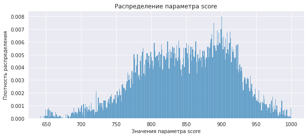

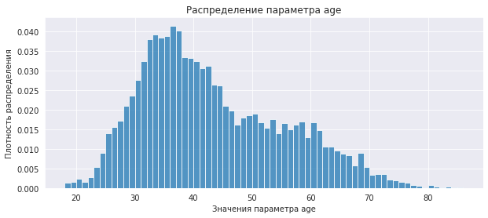

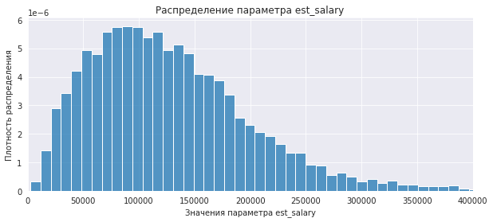

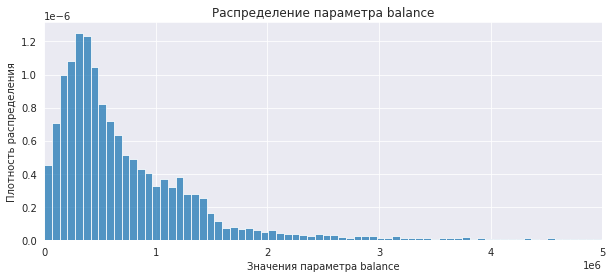

```python
#распределения количественных переменных
for column in ['score', 'age', 'est_salary', 'balance']:
    plt.figure(figsize= (10, 4))
    if column == 'est_salary':
        plt.xlim([0, 400000])
        sns.histplot(data=bank_clients, x=column, stat='density', common_norm=False)
    elif column == 'balance':
        plt.xlim([0, 5000000])
        sns.histplot(data=bank_clients[bank_clients['balance'].notnull()], x=column, stat='density', common_norm=False)
    else:
        sns.histplot(data=bank_clients, x=column, binwidth=1, stat='density', common_norm=False)
    plt.ylabel('Плотность распределения')
    plt.xlabel('Значения параметра ' + column)
    plt.title('Распределение параметра '+ column)
    plt.show()
    print();
```

- Распределение параметра 'age' напоминает нормальное распределение Гаусса со смещением вправо.
- Распределения параметров 'est_salary', 'balance' близки к распределению Пуасона.
- Пик по параметру age приходится на 30-40 лет, по параметру 'est_salary' на 70-130 тыс.руб., по параметру balance на 180-420 т.р.  
  Шкалу по параметрам est_salary и balance необходимо было сократить (за счет выбросов) для должного визульного оформления.
- Распределение 'score' имеет два экстремума - 800-850 и 875-925 (второй более выраженный).

### Диаграммы распределения категориальных признаков.

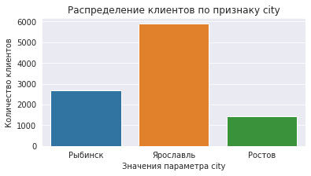

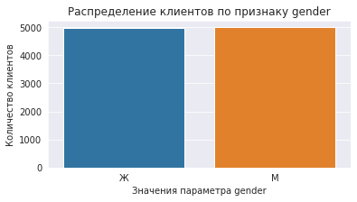

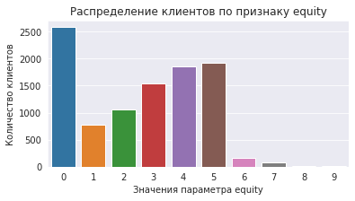

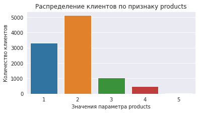

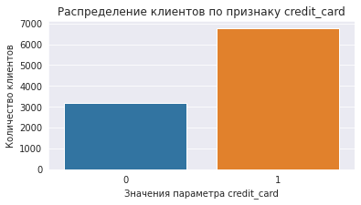

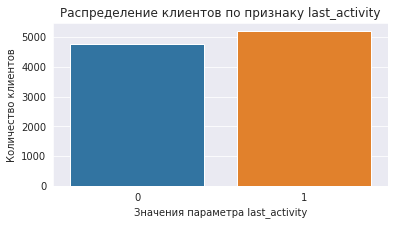

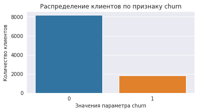

```python
#Построим диаграммы для категориальных признаков
for column in ['city', 'gender', 'equity', 'products', 'credit_card', 'last_activity', 'churn']:
    plt.figure(figsize=(6,3))
    sns.countplot(data=bank_clients, x=column)
    plt.xlabel('Значения параметра ' + column)
    plt.ylabel('Количество клиентов')
    plt.title('Распределение клиентов по признаку ' + column)
    plt.show()
```

- В Ярославле клиентов существенно больше, чем в других городах. На втором месте Рыбинск, затем Ростов.
- мужчин и женщин примерно поровну.
- больше всего клиентов с нулевым значением параметра equity. Если отбросить нулевое значение, то у оставшихся клиентов значение equity, как правило, не более 5, причем чаще всего клиенты имеют значение 5, потом 4, 3, 2, 1 - в обратном пордяке. Только небольшое количество клиентов имеют значение equity 6 и более.
- в основном клиенты имеют 1 или 2 продукта. Небольшая часть клиентов имеет 3 или 4 продукта. 5 продуктов почти ни у кого нет.
- клиентов имеющих кредитную карту намного больше, чем тех, кто кредитную карту не имеет. Без кредитной карты примерно 30% клиентов.
- активных и неактивных клиентов примерно поровну.
- отточных клиентов около 20%.

### Матрица корреляций признаков.

Воспользуемся библиотекой phik для анализа корреляции между признаками.  
Чтобы города можно было анализировать как отдельные единицы, добавим новые колонки с названиями городов, имеющие индикаторные значения 0 или 1 (1 - если есть такой признак, 0 - если нет) методом get_dummies.

```
interval columns not set, guessing: ['userid', 'score', 'age', 'equity', 'balance', 'products', 'credit_card', 'last_activity', 'est_salary', 'churn', 'city_Ростов', 'city_Рыбинск', 'city_Ярославль', 'gender_Ж', 'gender_М']
```

[figure not shown]

```python
#строим матрицу корреляций признаков
phik_overview = pd.get_dummies (bank_clients, columns=['city', 'gender'], drop_first=False).phik_matrix()
plot_correlation_matrix(phik_overview[['score', 'city_Ростов', 'city_Рыбинск', 'city_Ярославль', 'gender_М', \
            'age', 'equity', 'balance', 'credit_card', 'last_activity', 'est_salary','products', 'churn']].values,
            x_labels=phik_overview[['score', 'city_Ростов', 'city_Рыбинск', 'city_Ярославль', 'gender_М', \
            'age', 'equity', 'balance', 'credit_card', 'last_activity', 'est_salary', 'products', 'churn']].columns,
            y_labels=phik_overview[['score', 'city_Ростов', 'city_Рыбинск', 'city_Ярославль', 'gender_М', \
            'age', 'equity', 'balance', 'credit_card', 'last_activity', 'est_salary', 'products', 'churn']].index,
            vmin=0, vmax=1, color_map="Greens",
            title=r"Корреляция $\phi_K$",
            fontsize_factor=1.2,
            figsize=(14, 6))
plt.tight_layout();
```

На основе парных коэффициентов корреляции 𝜙k можем сделать следующие выводы. Наибольшую корреляцию c параметром продуктов (products) имеют показатели:

- equity (0.58),
- score (0.42),
- credit_card (0.27)
- churn (0.26),
- est_salary (0.22),
- age (0.14).

Другие пары параметров с высокой корреляцией:

- eat_salary-score (0.4), est_salary-balance (0.37), est_salary-age (0.36), est_salary-equity (0.29).
- equity-score (0.53).
- gender-age (0.29).

## Сегментация клиентов по числу используемых продуктов.

```python
display('Средние значения параметров по клиентам с заданным количеством продуктов: ', \
        pd.get_dummies (bank_clients, columns=['gender', 'city'], drop_first=False)\
        .groupby('products').mean().round(2).reset_index())
```

```
'Средние значения параметров по клиентам с заданным количеством продуктов: '
```

|  | products | userid | score | age | equity | balance | credit_card | last_activity | est_salary | churn | gender_Ж | gender_М | city_Ростов | city_Рыбинск | city_Ярославль |
| --- | --- | --- | --- | --- | --- | --- | --- | --- | --- | --- | --- | --- | --- | --- | --- |
| 0 | 1 | 4986.18 | 854.30 | 42.20 | 1.33 | 611006.20 | 0.86 | 0.53 | 180605.23 | 0.07 | 0.46 | 0.54 | 0.13 | 0.26 | 0.61 |
| 1 | 2 | 4990.55 | 844.56 | 42.77 | 3.15 | 812152.00 | 0.63 | 0.52 | 130400.38 | 0.19 | 0.52 | 0.48 | 0.16 | 0.30 | 0.54 |
| 2 | 3 | 4972.63 | 837.24 | 45.71 | 3.52 | 993888.30 | 0.36 | 0.42 | 128697.01 | 0.29 | 0.57 | 0.43 | 0.09 | 0.16 | 0.75 |
| 3 | 4 | 5012.98 | 878.27 | 39.78 | 4.15 | 1267820.57 | 0.68 | 0.79 | 148788.95 | 0.63 | 0.38 | 0.62 | 0.14 | 0.21 | 0.65 |
| 4 | 5 | 3839.00 | 859.26 | 36.47 | 3.68 | 610986.63 | 1.00 | 0.89 | 116652.05 | 0.42 | 0.47 | 0.53 | 0.21 | 0.05 | 0.74 |

```python
display('Количество клиентов с заданным количеством продуктов: ', bank_clients.groupby('products')['userid'].count())
```

```
'Количество клиентов с заданным количеством продуктов: '
```

```
products
1    3323
2    5119
3    1038
4     474
5      19
Name: userid, dtype: int64
```

```python
#обЪединим пользователей с 3, 4 и 5 продуктами
bank_clients_new = bank_clients
bank_clients_new.loc[bank_clients_new['products']== 5, 'products'] = 4
bank_clients_new.loc[bank_clients_new['products']== 4, 'products'] = 3
```

```python
display('Средние значения параметров по клиентам с заданным количеством продуктов: ', \
        pd.get_dummies (bank_clients_new, columns=['gender', 'city'], drop_first=False)\
        .groupby('products').mean().round(2).reset_index())
```

```
'Средние значения параметров по клиентам с заданным количеством продуктов: '
```

|  | products | userid | score | age | equity | balance | credit_card | last_activity | est_salary | churn | gender_Ж | gender_М | city_Ростов | city_Рыбинск | city_Ярославль |
| --- | --- | --- | --- | --- | --- | --- | --- | --- | --- | --- | --- | --- | --- | --- | --- |
| 0 | 1 | 4986.18 | 854.30 | 42.20 | 1.33 | 611006.2 | 0.86 | 0.53 | 180605.23 | 0.07 | 0.46 | 0.54 | 0.13 | 0.26 | 0.61 |
| 1 | 2 | 4990.55 | 844.56 | 42.77 | 3.15 | 812152.0 | 0.63 | 0.52 | 130400.38 | 0.19 | 0.52 | 0.48 | 0.16 | 0.30 | 0.54 |
| 2 | 3 | 4971.06 | 850.22 | 43.76 | 3.72 | 1075492.0 | 0.46 | 0.54 | 134768.02 | 0.40 | 0.51 | 0.49 | 0.11 | 0.17 | 0.72 |

В группе 3 (3, 4 и 5 продуктов):

- наибольший процент оттока клиентов - 40%.

По всем группам большая часть клиентов обслуживается в Ярославле.  
В 1 и 2 группах более 63% клиентов имеют кредитную карту. Тогда, как в 3 группе имеют кредитную карту только 46%.  
В первой группе у клиентов один продукт, который в 86% случаев является кредитной картой. У таких клиентов процент оттока только 7%, что значительно ниже среднего оттока по банку (18%).

### Графики распределения всех имеющихся параметров с учетом параметра количества продуктов у клиентов (products)

Далее построим диаграммы распределения параметров с учетом наличия продуктов у клиентов.

```python
def diagramms(df, hue=None): #Функция построения диаграмм распределения параметров, в т.ч. с учетом параметра hue.

    #распределения количественных переменных с учетом количества продуктов
    for column in ['score', 'age', 'est_salary', 'balance']:
        plt.figure(figsize= (10, 4))
        if column == 'est_salary':
            plt.xlim([0, 400000])
            sns.histplot(data=df, x=column, stat='density', hue=hue, kde=True, common_norm=False)
        elif column == 'balance':
            plt.xlim([0, 5000000])
            sns.histplot(data=df[df['balance'].notnull()], x=column, stat='density', hue=hue, \
                     kde=True, common_norm=False)
        else:
            sns.histplot(data=df, x=column, binwidth=1, stat='density', hue=hue, kde=True, common_norm=False)
        plt.ylabel('Плотность распределения')
        plt.xlabel('Значения параметра ' + column + ' с учетом количества продуктов')
        plt.title('Распределение параметра '+ column + ' с учетом параметра '  + hue)
        plt.show()

    #Построим диаграммы для категориальных признаков с учетом количества продуктов
    for column in ['city', 'gender', 'equity', 'products', 'credit_card', 'last_activity', 'churn']:
        plt.figure(figsize=(6,3))
        sns.countplot(data=df, x=column, hue=hue)
        plt.xlabel('Значения параметра ' + column)
        plt.ylabel('Количество клиентов')
        plt.title('Распределение клиентов по признаку ' + column + ' с учетом параметра ' + hue)
        plt.show()


    print();
```

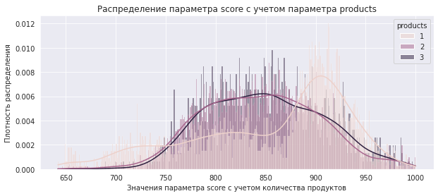

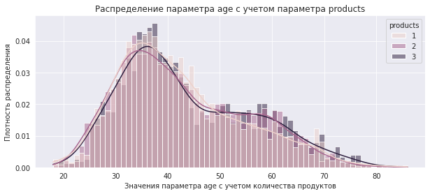

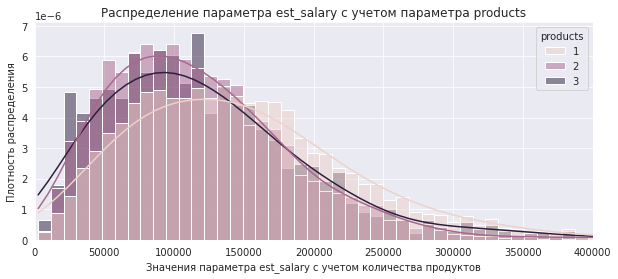

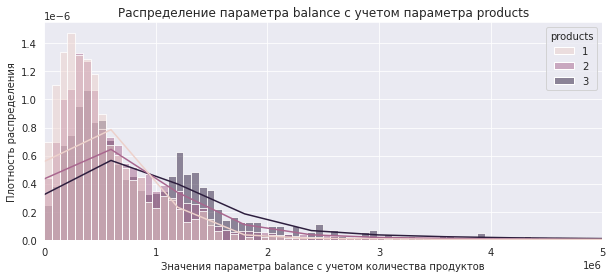

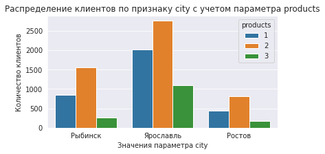

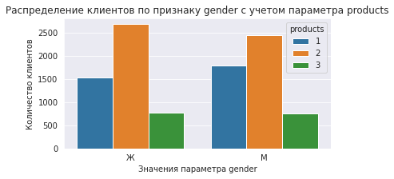

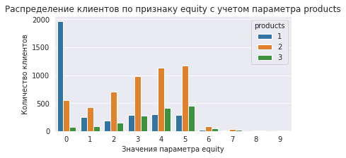

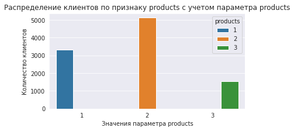

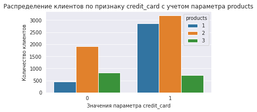

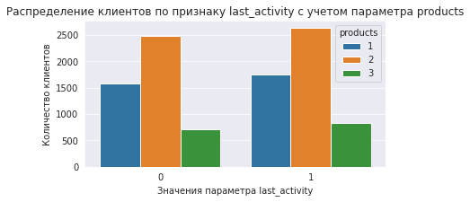

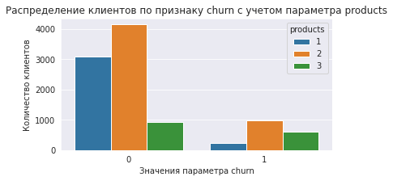

```python
diagramms(bank_clients_new, hue='products')
```

- Распределение параметра score: наибольший показатель в группе 1, затем группа 3, далее группа 2.
- Распределение параметра age: во всех группах пик 30-42 года и само распределение практически не различается, за исключением возраста более 50 лет. В 3 группе клиентов старше 50 лет больше всего.
- Распределение параметра est_salary похоже во всех группах, но значение чуть выше в группе 1.
- Распределение параметра баланс: до 1 млн руб - наибольшие значения в группах 1,2. Свыше 1 млн руб. - в группе 3.
- По всем продуктам клиенты чаще всего из Ярославля.
- Мужчин больше в группе 1, а женщин в группах 2 и 3.
- Значения параметра equity 5 и 4 преобладают во всех группах, кроме 1. В первой группе преобладает значение 0.
- Во всех группах, кроме 3 (ярче всего в 1 группе) заметно больше клиентов, имеющих кредитные карты.
- Активных и неактивных клиентов примерно равное количество во всех группах.
- Наибольший отток клиентов наблюдается во 2 группе. Также существенный показатель оттока в третьей группе.

### Графики распределения всех имеющихся параметров с учетом параметра оттока клиентов (churn).

Для категорийных парамтеров city, gender построим столбчатые диаграммы.

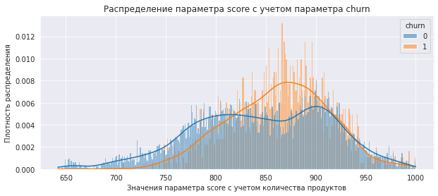

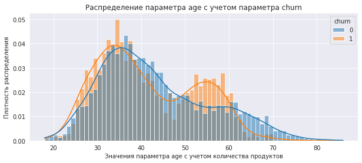

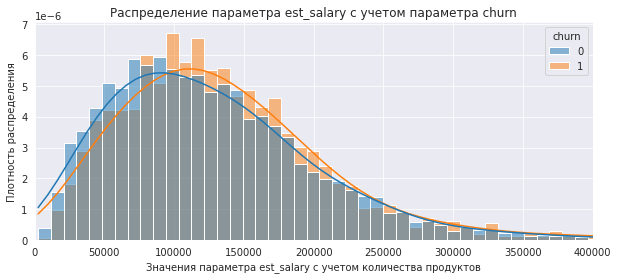

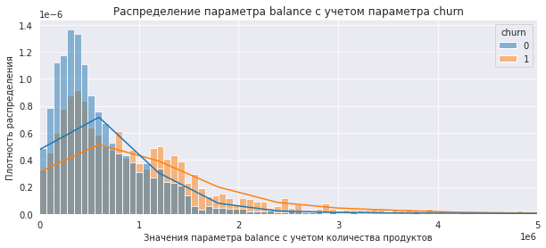

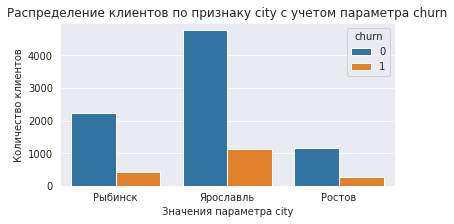

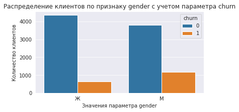

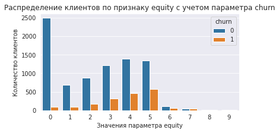

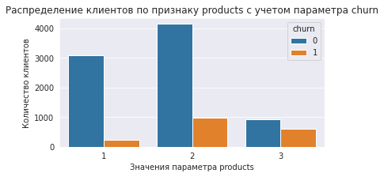

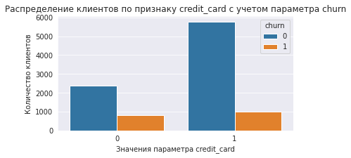

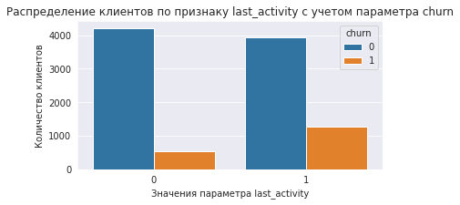

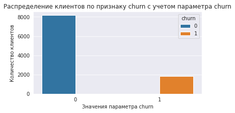

```python
diagramms(bank_clients_new, hue='churn')
```

Менее склонные к уходу клиенты: gender: Женщина  
age: 35-50 или более 60 лет  
equity: 0  
products: 1  
balance: менее 1 млн. руб.  
credit_card: Клиент с кредитной картой  
est_salary: до 100 тыс. руб.

### Выделение сегментов клиентов

Выделим сегменты клиентов внутри продуктовых групп для дальнейшего анализа по параметрам, которые имеют наибольшую корреляцию с оттоком: equity, products, last_activity, score, gender, credit_card, age, balance, est_salary

```python
#рассчитаем показатели оттока и количества клиентов по параметрам внутри продуктовых групп (1-3)
for i in range (1, 4): #расчитаем показатели по каждой продуктовой группе отдельно
        print('Значения показателей в группе c количеством продуктов ',  i ,':')
        total_avg_churn = bank_clients_new[bank_clients_new['products']==i]['churn'].mean()
        print ('Средний показатель оттока по банку', total_avg_churn.round(2))
        churn_parameters = pd.Series(round(bank_clients_new[bank_clients_new['products']==i]\
                                          .query('((equity==4)|(equity==5))')['churn'].mean(), 2))
        churn_parameters = pd.DataFrame(churn_parameters, columns=['churn'])
        churn_parameters['count'] = bank_clients_new[bank_clients_new['products']==i]\
                             .query('((equity==4)|(equity==5))').count()['userid']
        churn_parameters = churn_parameters.append({\
                        'churn': round(bank_clients_new[bank_clients_new['products']==i]\
                                          .query('last_activity==1')['churn'].mean(), 2), \
                        'count': round(bank_clients_new[bank_clients_new['products']==i]\
                             .query('last_activity==1').count()['userid'], 0)}, ignore_index = True)
        churn_parameters = churn_parameters.append({\
                        'churn': round(bank_clients_new[bank_clients_new['products']==i]\
                                          .query("(score>=825)&(score<=910)")['churn'].mean(), 2), \
                        'count': round(bank_clients_new[bank_clients_new['products']==i]\
                             .query("(score>=825)&(score<=910)").count()['userid'], 0)}, ignore_index = True)
        churn_parameters = churn_parameters.append({\
                        'churn': round(bank_clients_new[bank_clients_new['products']==i]\
                                          .query('credit_card==1')['churn'].mean(), 2), \
                        'count': round(bank_clients_new[bank_clients_new['products']==i]\
                             .query('credit_card==1').count()['userid'], 0)}, ignore_index = True)
        churn_parameters = churn_parameters.append({\
                        'churn': round(bank_clients_new[bank_clients_new['products']==i]\
                                          .query("gender=='М'")['churn'].mean(), 2), \
                        'count': round(bank_clients_new[bank_clients_new['products']==i]\
                             .query("gender=='М'").count()['userid'], 0)}, ignore_index = True)
        churn_parameters = churn_parameters.append({\
                        'churn': round(bank_clients_new[bank_clients_new['products']==i]\
                                          .query("(age>=25)&(age<=35)")['churn'].mean(), 2), \
                        'count': round(bank_clients_new[bank_clients_new['products']==i]\
                             .query("(age>=25)&(age<=35)").count()['userid'], 0)}, ignore_index = True)
        churn_parameters = churn_parameters.append({\
                        'churn': round(bank_clients_new[bank_clients_new['products']==i]\
                                          .query('balance > 1000000')['churn'].mean(), 2), \
                        'count': round(bank_clients_new[bank_clients_new['products']==i]\
                             .query('balance > 1000000').count()['userid'], 0)}, ignore_index = True)
        churn_parameters = churn_parameters.append({\
                        'churn': round(bank_clients_new[bank_clients_new['products']==i]\
                                          .query("(est_salary>=100000)&(est_salary<=200000)")['churn'].mean(), 2), \
                        'count': round(bank_clients_new[bank_clients_new['products']==i]\
                        .query("(est_salary>=100000)&(est_salary<=200000)").count()['userid'], 0)}, ignore_index = True)
        churn_parameters['share, %'] = round(churn_parameters['count'] / \
                                           bank_clients_new[bank_clients_new['products']==i].shape[0]*100, 2)
        churn_parameters.index = ['Количество объектов в собственности 4-5', 'Активный клиент',  \
                                 'Скорринговый бал 825-910', 'Есть кредитная карта', 'Мужчина', \
                                  'Возраст 25-35 лет', 'Баланс более 1 млн.руб.', \
                                  'Оцен. заработ.плата от 100 до 200 тыс.руб.']
        cm = sns.light_palette("blue", as_cmap=True)

        display(churn_parameters.style.background_gradient(cmap=cm).set_precision(2).highlight_null('red')\
                .highlight_min(axis=0, color='white').highlight_max(axis=0, color='green'))
```

```
Значения показателей в группе c количеством продуктов  1 :
Средний показатель оттока по банку 0.07
```

|  | churn | count | share, % |
| --- | --- | --- | --- |
| Количество объектов в собственности 4-5 | 0.17 | 584.00 | 17.57 |
| Активный клиент | 0.09 | 1753.00 | 52.75 |
| Скорринговый бал 825-910 | 0.10 | 1320.00 | 39.72 |
| Есть кредитная карта | 0.07 | 2870.00 | 86.37 |
| Мужчина | 0.10 | 1796.00 | 54.05 |
| Возраст 25-35 лет | 0.08 | 1048.00 | 31.54 |
| Баланс более 1 млн.руб. | 0.18 | 197.00 | 5.93 |
| Оцен. заработ.плата от 100 до 200 тыс.руб. | 0.07 | 1476.00 | 44.42 |

```
Значения показателей в группе c количеством продуктов  2 :
Средний показатель оттока по банку 0.19
```

|  | churn | count | share, % |
| --- | --- | --- | --- |
| Количество объектов в собственности 4-5 | 0.24 | 2314.00 | 45.20 |
| Активный клиент | 0.28 | 2639.00 | 51.55 |
| Скорринговый бал 825-910 | 0.26 | 2459.00 | 48.04 |
| Есть кредитная карта | 0.14 | 3203.00 | 62.57 |
| Мужчина | 0.26 | 2443.00 | 47.72 |
| Возраст 25-35 лет | 0.25 | 1561.00 | 30.49 |
| Баланс более 1 млн.руб. | 0.33 | 1078.00 | 21.06 |
| Оцен. заработ.плата от 100 до 200 тыс.руб. | 0.22 | 2206.00 | 43.09 |

```
Значения показателей в группе c количеством продуктов  3 :
Средний показатель оттока по банку 0.4
```

|  | churn | count | share, % |
| --- | --- | --- | --- |
| Количество объектов в собственности 4-5 | 0.44 | 864.00 | 56.43 |
| Активный клиент | 0.48 | 823.00 | 53.76 |
| Скорринговый бал 825-910 | 0.44 | 734.00 | 47.94 |
| Есть кредитная карта | 0.48 | 711.00 | 46.44 |
| Мужчина | 0.50 | 752.00 | 49.12 |
| Возраст 25-35 лет | 0.44 | 446.00 | 29.13 |
| Баланс более 1 млн.руб. | 0.55 | 598.00 | 39.06 |
| Оцен. заработ.плата от 100 до 200 тыс.руб. | 0.45 | 621.00 | 40.56 |

*Объединим клиентов в сегменты:*

```
1. 1 продукт, количество объектов в собственности 4 или 5.
2. 2 продукта, баланс более 1 млн. руб., активный клиент.
3. 3 продукта, возраст 25-35 лет.
```

Рассчитаем показатели оттока и количество клиентов в сегментах.

```python
#рассчитаем показатели оттока и количества клиентов по каждому из сегментов клиентов (1-3)
#for i in range (1, 4): #расчитаем показатели по каждому сегменту отдельно
print('Значения показателей по выделенным сегментам клиентов :')
total_avg_churn = bank_clients_new['churn'].mean()
print ('Средний показатель оттока по банку', total_avg_churn.round(2))
churn_parameters = pd.Series(round(bank_clients_new[bank_clients_new['products']==1]\
                                          .query('((equity==4)|(equity==5))')['churn'].mean(), 2))
churn_parameters = pd.DataFrame(churn_parameters, columns=['churn'])
churn_parameters['count'] = bank_clients_new[bank_clients_new['products']==1]\
                             .query('((equity==4)|(equity==5))').count()['userid']
churn_parameters = churn_parameters.append({\
    'churn': round(bank_clients_new[bank_clients_new['products']==2]\
                   .query("(last_activity==1)&(balance > 1000000)")['churn'].mean(), 2), \
    'count': round(bank_clients_new[bank_clients_new['products']==2]\
                   .query("(last_activity==1)&(balance > 1000000)").count()['userid'], 0)}, ignore_index = True)
churn_parameters = churn_parameters.append({\
    'churn': round(bank_clients_new[bank_clients_new['products']==3]\
                   .query("(age>=25)&(age<=35)")['churn'].mean(), 2), \
    'count': round(bank_clients_new[bank_clients_new['products']==3]\
    .query("(age>=25)&(age<=35)").count()['userid'], 0)}, ignore_index = True)
churn_parameters.index = ['1 продукт, количество объектов в собственности 4-5', '2 продукта, активный клиент,\
                         баланс более 1 млн. руб.','3 и более продукта, возраст 25-35 лет']
display(churn_parameters.style.background_gradient(cmap=cm).set_precision(2).highlight_null('red')\
        .highlight_min(axis=0, color='white').highlight_max(axis=0, color='green'))
```

```
Значения показателей по выделенным сегментам клиентов :
Средний показатель оттока по банку 0.18
```

|  | churn | count |
| --- | --- | --- |
| 1 продукт, количество объектов в собственности 4-5 | 0.17 | 584.00 |
| 2 продукта, активный клиент, баланс более 1 млн. руб. | 0.49 | 570.00 |
| 3 и более продукта, возраст 25-35 лет | 0.44 | 446.00 |

## Статистическая проверка гипотез

### Гипотеза равенства возраста между теми клиентами, которые пользуются двумя продуктами банка, и теми, которые пользуются одним продуктом

Для проверки гипотезы сформируем две выборки данных в зависмости от количества продуктов: с 2 продуктами и 1 продуктом. В этих выборках будем сравнивать значения возраста клиентов.

```python
bank_clients_new1 = bank_clients_new.query('products == 1')['age']
bank_clients_new2 = bank_clients_new.query('products == 2')['age']
```

По этим данным гипотезу можно проверить:

- как методом для проверки гипотезы о равенстве среднего двух генеральных совокупностей по взятым из них выборкам t-тест (st.ttest_ind (array1, array2, equal_var=True)),
- так и непараметрическим тестом Уилкоксона-Манна-Уитни по критерию Манна-Уитни (st.mannwhitneyu(dataset_1, dataset_2, True, 'two-sided')), который проверяет однородность распределения параметров.

Для первого метода проверки, важны три аспекта, которые надо проверить, чтобы понять, можно ли применять t-тест:

1. Генеральные совокупности не должны зависеть друг от друга.
2. Выборочные средние должны быть нормально распределены.
3. Дисперсии рассматриваемых генеральных совокупностей должны быть равны.

```python
#проверка данных на нормальность распределения

for val in [bank_clients_new1, bank_clients_new2]:
    alpha = 0.05  # критический уровень статистической значимости

    results = st.shapiro(val)
    p_value = results[1]  # второе значение в массиве результатов (с индексом 1) - p-value

    print('p-значение: ', p_value)

    if p_value < alpha:
        print('Отвергаем нулевую гипотезу: распределение не нормально')
    else:
        print('Не получилось отвергнуть нулевую гипотезу, всё нормально')
```

```
p-значение:  2.7809143816725107e-30
Отвергаем нулевую гипотезу: распределение не нормально
p-значение:  7.941429186486062e-35
Отвергаем нулевую гипотезу: распределение не нормально
```

Мы имеем два независимых набора данных, которые не распределены нормально, поэтому для t-теста применяем значение equal_var=False

```python
# проверим значения дисперсий в данных
print(np.var(bank_clients_new1))
print(np.var(bank_clients_new2))
```

```
143.6425134588908
147.77878665911112
```

Дисперсии в данных похожи, но не равны.

**Сформулируем основную гипотезу и ее альтернативу:**

- Нулевая гипотеза H_0: Возраст клиентов, которые пользуются двумя продуктами банка, и тех, которые пользуются одним продуктом, не отличается.
- Альтернативная гипотеза H_1: Возраст клиентов, которые пользуются двумя продуктами банка, и тех, которые пользуются одним продуктом, отличается.

Критический уровень статистической значимости примем в размере alpha = 0.05

Сначала проверим отличается ли средний возраст клиентов с 1 и 2 продуктам с помощью t-теста.

```python
#проверим гипотезу о равенстве среднего возраста в группах двусторонним t-тестом Стьюдента

alpha = 0.05
results = st.ttest_ind(bank_clients_new1, bank_clients_new2, equal_var=False)

print('p-значение:', "{0:.4f}".format(results.pvalue))

if (results.pvalue < alpha):
    print("Отвергаем нулевую гипотезу: разница статистически значима")
else:
    print("Не получилось отвергнуть нулевую гипотезу, вывод о различии сделать нельзя")
```

```
p-значение: 0.0330
Отвергаем нулевую гипотезу: разница статистически значима
```

Теперь проверим изменился ли возраст клиентов с 2 продуктами по сравнению с клиентами с 1 продуктом.

```python
#Посчитаем статистическую значимость различия в возрасте между группами.
#Применим критерий Манна-Уитни и отформатируем p-value, округлив его до 4 знаков после запятой.

alpha = 0.05 # критический уровень статистической значимости
results = st.mannwhitneyu(bank_clients_new1, bank_clients_new2)
print('p-значение: ',"{0:.4f}".format(results[1]))

if results[1] < alpha:
    print('Отвергаем нулевую гипотезу: разница статистически значима')
else:
    print('Не получилось отвергнуть нулевую гипотезу, вывод о различии сделать нельзя')
```

```
p-значение:  0.0571
Не получилось отвергнуть нулевую гипотезу, вывод о различии сделать нельзя
```

Проверка гипотезы t-тестом показала, что средний возраст клиентов с 1 продуктом и двумя продуктами отличается. В тоже время проверка гипотезы криетрием Манна-Уитни отличий в возрасте сравниваемых групп данных не выявила.  
Учитывая, что критерий Манна-Уитни менее чувствителен к выбросам в данных, а также то, что наши данные не полностью отвечают требованиям проведения t-теста (распределены данные не нормально), в данном случае критерий Манна-Уитни больше подходит для проверки вышеуказанной гипотезы.  
**Таким образом, согласно непараметрического теста Уилкоксона-Манна-Уитни нет статистически значимой разницы в возрасте клиентов, которые пользуются двумя продуктами банка, и клиентов, которые пользуются одним продуктом.**

### Гипотеза равенства оценочной заработной платы у клиентов с 2 продуктами и клиентов с 1 продуктом.

Для проверки гипотезы сформируем две выборки данных в зависмости от количества продуктов: с 2 продуктами и 1 продуктом. В этих выборках будем сравнивать значения заработной платы клиентов.

```python
bank_clients_news1 = bank_clients_new.query('products == 1')['est_salary']
bank_clients_news2 = bank_clients_new.query('products == 2')['est_salary']
```

Также проверим гипотезу двусторонним t-тестом Стьюдента и критерием Манна-Уитни.

```python
#проверка данных на нормальность распределения

for val in [bank_clients_news1, bank_clients_news2]:
    alpha = 0.05  # критический уровень статистической значимости

    results = st.shapiro(val)
    p_value = results[1]  # второе значение в массиве результатов (с индексом 1) - p-value

    print('p-значение: ', p_value)

    if p_value < alpha:
        print('Отвергаем нулевую гипотезу: распределение не нормально')
    else:
        print('Не получилось отвергнуть нулевую гипотезу, всё нормально')
```

```
p-значение:  0.0
Отвергаем нулевую гипотезу: распределение не нормально
p-значение:  0.0
Отвергаем нулевую гипотезу: распределение не нормально
```

Наборы данных не имеют нормального распрелеления.

```python
# проверим значения дисперсий в данных
print(np.var(bank_clients_news1))
print(np.var(bank_clients_news2))
```

```
28691067055.391853
13704251091.594791
```

Дисперсии в данных не равны.

**Сформулируем основную гипотезу и ее альтернативу:**

- Нулевая гипотеза H_0: оценочная заработная плата у клиентов, которые пользуются двумя продуктами банка, и тех, которые пользуются одним продуктом, не отличается.
- Альтернативная гипотеза H_1: оценочная заработная плата у клиентов, которые пользуются двумя продуктами банка, и тех, которые пользуются одним продуктом, отличается.

Критический уровень статистической значимости примем в размере alpha = 0.05

```python
#проверим гипотезу о равентве средних оценочных заработных плат групп двусторонним t-тестом Стьюдента

alpha = 0.05
results = st.ttest_ind(bank_clients_news1, bank_clients_news2, equal_var=False)

print('p-значение:', "{0:.4f}".format(results.pvalue))

if (results.pvalue < alpha):
    print("Отвергаем нулевую гипотезу: разница статистически значима")
else:
    print("Не получилось отвергнуть нулевую гипотезу, вывод о различии сделать нельзя")
```

```
p-значение: 0.0000
Отвергаем нулевую гипотезу: разница статистически значима
```

```python
#Посчитаем статистическую значимость различия в оценочной заработной плате между группами.
#Применим критерий Манна-Уитни и отформатируем p-value, округлив его до 4 знаков после запятой.

alpha = 0.05 # критический уровень статистической значимости
results = st.mannwhitneyu(bank_clients_news1, bank_clients_news2)
print('p-значение: ', "{0:.4f}".format(results[1]))

if results[1] < alpha:
    print('Отвергаем нулевую гипотезу: разница статистически значима')
else:
    print('Не получилось отвергнуть нулевую гипотезу, вывод о различии сделать нельзя')

#Выведем относительный прирост средней оценочной заработной платы по клиентам с 1 продуктом по отношению\
#к клиентам с 2 продуктами:
print('{0:.3f}'.format(bank_clients_news1.mean()/bank_clients_news2.mean()-1))
```

```
p-значение:  0.0000
Отвергаем нулевую гипотезу: разница статистически значима
0.385
```

Относительный выигрыш клиентов с 1 продуктом по средней оценочной заработной плате составляет 38.5%

Проверка гипотезы t-тестом показала, что средняя оценочная заработная плата у клиентов, которые пользуются двумя продуктами банка, и тех, которые пользуются одним продуктом, отличаются. Проверка гипотезы криетрием Манна-Уитни также показала разницу между группами по оценочной заработной плате.  
**Таким образом, согласно проведенной проверки гипотезы, можно сделать вывыод, что имеется статистически значимая разница между оценочной заработной платой у клиентов, которые пользуются двумя продуктами банка, и клиентов, которые пользуются одним продуктом.**

## Выводы и рекомендации по удержанию продуктов сегментов

**1. По разделу 1 и 2 о знакомстве с данными и их предобработке:** Анализ данных для строк с пропуском в колонке balance показал, что в не менее, чем в 75% случаев имеется один единственный продукт - и это кредитная карта. По какой-то причине у таких клиентов информации о балансе нет. Было бы хорошо уточнить у менеджера продукта как формируются данные о балансе у таких клиентов, и почему в этом конкретном случае таких данных вообще нет. Заполнять или удалять эти данные не стали, и оставили как есть, учитывая их высокую долю в обработанных данных 22,85%. В таблице после обработки осталось 9973 строк.

Менее склонные к уходу клиенты: - gender: Женщина - age: 35-50 или более 60 лет - equity: 0 - products: 1 - balance: менее 1 млн. руб. - credit_card: Клиент с кредитной картой - est_salary: до 100 тыс. руб.

3.3. При группировке клиентов по продуктам наибольший процент оттока клиентов 40% наблюдается в группе 3 (3, 4 и 5 продуктов). По всем группам большая часть клиентов обслуживается в Ярославле. В группах с 1 и 2 продуктами более 63% клиентов имеют кредитную карту. Тогда, как в группе с 3 продуктами и более имеют кредитную карту только 46% клиентов. В группе с 1 продуктом, в 86% случаев этот продукт - кредитная карта. У таких клиентов процент оттока только 7%, что значительно ниже среднего оттока по банку (18%).

**4. По разделу 5 о статистической проверке гипотез:**  
4.1. Мы не подтвердили какую-либо статистически значимую разницу в возрасте клиентов, которые пользуются двумя продуктами банка, и клиентов, которые пользуются одним продуктом. 4.2. Мы подтвердили статистически значимую разницу между оценочной заработной платой у клиентов, которые пользуются двумя продуктами банка, и клиентов, которые пользуются одним продуктом. Относительный выигрыш клиентов с 1 продуктом по средней оценочной заработной плате составляет 38.5%. **5. Рекомендации по удержанию продуктов сегментов:**  
``- Сегмент 1``: *1 продукт, количество объектов в собственности 4 или 5.* Для даного сегмента было бы хорошо расширить использование кредитных продуктов: потребительский кредит, автокредит, ипотека, как более длинные и дешевые деньги, чем по кредитной карте - могут быть интересны клиентам. Может быть, есть возможность повысить лимит по кредитной карте (т.к. 86% таких клиентов уже имеют крединтую карту) или предложить выбрать другую карту с более интересными условиями по кэшбеку и прочими бонусами, что может повысить лояльность клиента. ``- Сегмент 2``: *2 продукта, баланс более 1 млн. руб., активный клиент.* Клиентам с таким балансом могут быть интересны депозиты, индивидуальный инвестиционный или брокерский счет. Подходят для таких клиентов ипотечные программы и страховые продукты, а также карты с кешбэком и различными привилегиями. ``- Сегмент 3``: *3 продукта, возраст 25-35 лет.* Данные клиенты активно используют различные продукты банка и, возможно, не только этого банка, а также интересуются продуктами для накопления капитала. Для таких клиентов можно было бы предложить программы рефинансирования: ипотеки, автокредитов, потребкредитов, страхование - как продуктов наиболее востребованных в этой возрастной категории. Можно также предложить дебетовые зарплатные карты, чтобы клиенты имели возможность оформлять кредитные продукты по более выгодным ставкам. Депозитные продукты также могут заинтересовать данных клиентов.

## Материалы: ссылки на презентацию и дашборд

### Cсылка на презентацию

[Сегментация клиентов регионального банка и анализ оттока клиентов](https://drive.google.com/file/d/1FG03Gl4kMNS2m-u9YWzH56jGeN64RAb3/view?usp=sharing)

### Cсылка на Дашборд

[Интерактивный дашборд "Количество клиентов в зависимости от числа используемых продуктов"](https://public.tableau.com/app/profile/s.s6552/viz/clients_segments/Dashboard1?publish=yes)